# Aula 6

Mahayana Godoy

# Teste-t com duas amostras

# Conteúdo

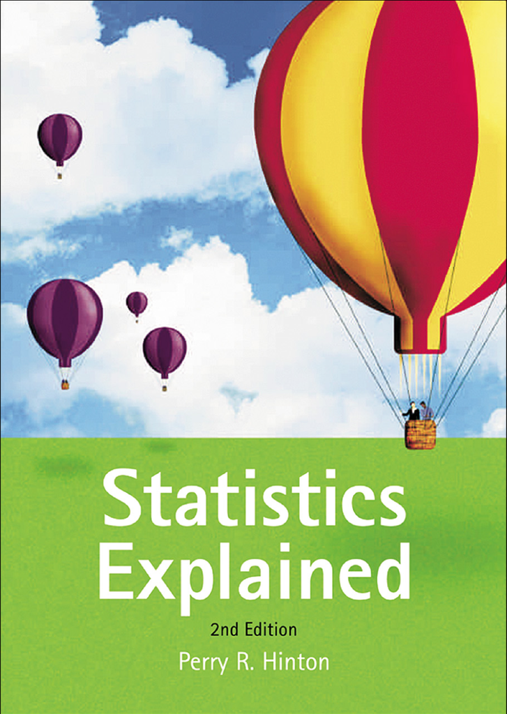

- Teste-t com duas amostras
- Análises práticas com teste-t
- Teste de Wilcoxon: opção ao teste-t

# Teste-t: 2 amostras

# Comparação de amostras

- padrão na ciência é comparar amostras
- imagine que se quer investigar se a prática de exercício físico diminui o colesterol total (valor de referência para adultos < 190mg/dl). Como você faria isso?
- Como você selecionaria essas amostras?

# Teste-t: duas amostras

Grupo A: n = 30, nunca pratica atividades físicas

Grupo B: n = 30, pratica atividade física 5x na semana

Duas amostras, uma para cada grupo, com os valores do colesterol dos 30 indivíduos.

No teste-t de uma amostra, eu comparava a média da amostra com uma média previamente dada.

No teste-t com duas amostras, quero saber se as médias de A e B podem ter vindo da distribuição amostral da média de uma mesma população.

$H_0$: $\mu_A$ = $\mu_B$

$H_A$: $\mu_A$ > $\mu_B$

# Teste-t: duas amostras

Se $\mu_A$ = $\mu_B$, então $\mu_A$ - $\mu_B$ = 0. Vejamos:

```r
A = rnorm(30, 200, 8) # gera o conjunto A, com 30 observações, média = 200, dp = 8
B = A # gera o conjunto B com os mesmos valores do conjunto A

mean(A)-mean(B)
```

```
## [1] 0
```

```r
B = rnorm(30, 202, 8) # gera conjunto B, com 30 observações, média = 202, dp = 8

mean(A)-mean(B)
```

```
## [1] -1.70436
```

# Teste-t: duas amostras

```r
B = rnorm(30, 150, 8) # gera o conjunto B, com 30 observações, média = 150, dp = 8

mean(A)-mean(B)
```

```
## [1] 46.16426
```

# Teste-t: duas amostras

Se $\mu_A$ = $\mu_B$, então $\mu_A$ - $\mu_B$ = 0.

No entanto, eu não tenho os valores de $\mu_A$ e $\mu_B$, mas sim os valores de $\bar{X}_A$ e $\bar{X}_B$

A partir das amostras A e B, eu calculo a distribuição amostral das médias para a população A e população B e infiro se $\mu_A$ = $\mu_B$ ou $\mu_A$ ≠ $\mu_B$

**Perceba como é importante a amostra seja representativa da população sobre a qual queremos generalizar nossos achados, ou então como é importante sermos parcimoniosos ao reportar os achados de uma *amostra de conveniência*.**

# Teste-t de duas amostras: prática

Felizmente, podemos deixar de lado os detalhes matemáticos para calcular o valor de $t$ que lhe dará um p-valor.

O que você precisa saber é:

1. Você está fazendo um teste-t, e sabemos que o valor desse teste sofre influência dos graus de liberdade (n-1);
2. Você está interessado em saber se a diferença das médias de duas populações é igual a 0, pelas razões já explicadas acima;
3. Você precisa definir qual é sua $H_0$ e $H_A$ considerando o disposto no item acima;
4. Você precisa saber se suas duas amostras são pareadas ou não-pareadas (às vezes elas são chamadas de dependentes e independentes)

# Teste-t de duas amostras: prática

Para fins de ilustração, vamos simular duas amostras de Grupo A e Grupo B para nosso experimento sobre colesterol

```r
sedentarios = rnorm(30, 200, sd = 15)
ativos = rnorm(30, 170, sd = 15)
```

Os participantes dos dois grupos são os mesmos ou são indivíduos diferentes?

- R: São diferentes. Portanto, precisamos fazer um teste-t não-pareado, o que significa dizer que os valores dos dois grupos não foram produzidos pela mesma “fonte”.
- **ATENÇÃO: estamos trabalhando com dados simulados; portanto, os valores e gráficos que você pode gerar a partir de agora, no seu computador, podem ser um pouco diferentes dos apresentados nos slides seguintes**

# Teste-t de duas amostras: prática

Com o comando abaixo, você faz um boxplot rápido dos grupos só para conferir se a distribuição dos dados é mesmo uma normal e para já dar uma olhada na diferença das médias.

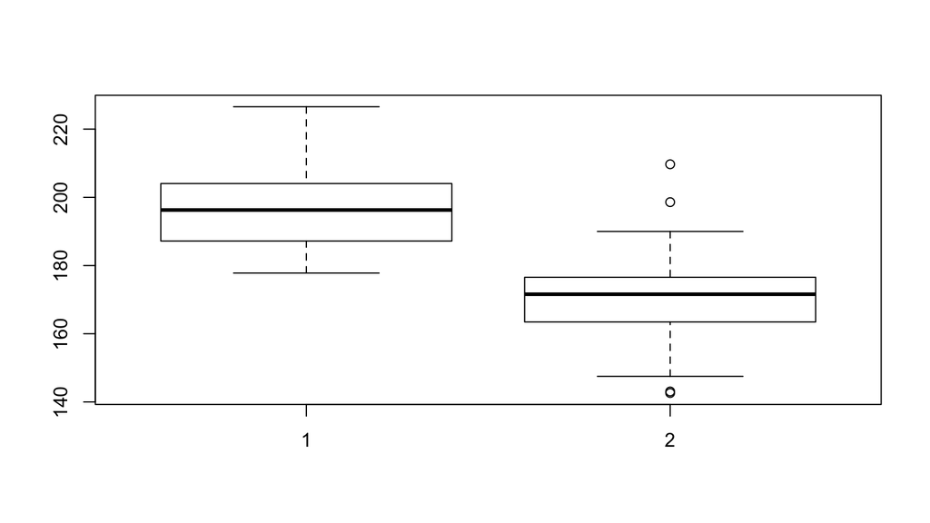

```r
boxplot(sedentarios, ativos)
```

# Teste-t de duas amostras: prática

Com o comando abaixo, você faz um histograma rápido dos grupos só para conferir se a distribuição dos dados é mesmo uma normal e para já dar uma olhada na diferença das médias.

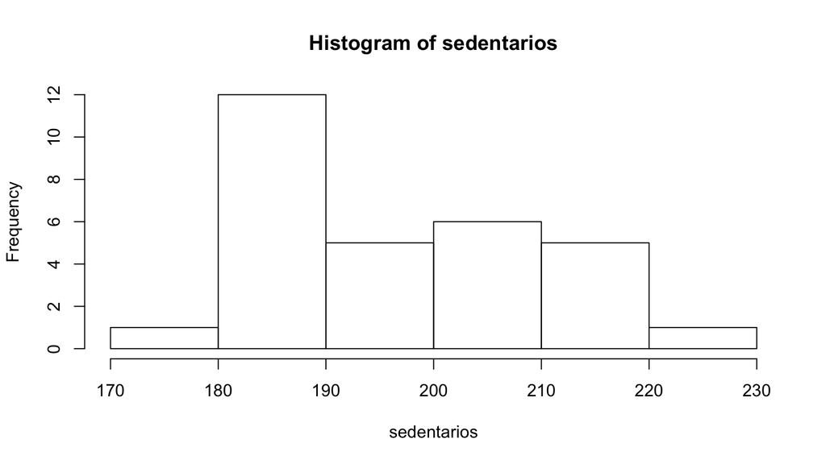

```r
hist(sedentarios)
```

# Teste-t de duas amostras: prática

Com o comando abaixo, você faz um histograma rápido dos grupos só para conferir se a distribuição dos dados é mesmo uma normal e para já dar uma olhada na diferença das médias.

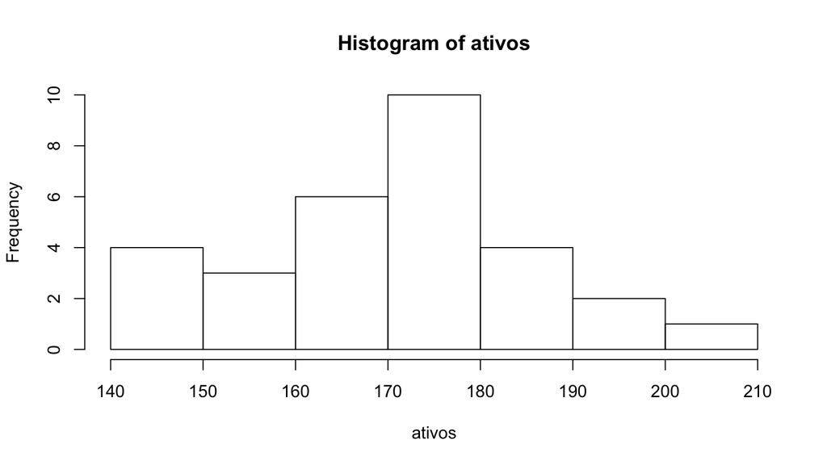

```r
hist(ativos)
```

# Teste-t de duas amostras: prática

Já sabemos que

- Nossas amostras são não-pareadas;
- A distribuição dos seus valores é normal;
- Os valores são uma variável numérica contínua;
- Os dados são independentes (ou seja, não tenho mais de uma medida de colesterol para cada participante)
- $H_0$:$\mu_A$ - $\mu_B$ = 0 e $H_A$: $\mu_A$ - $\mu_B$ > 0
- Podemos fazer o teste-t!

# Teste-t de duas amostras: prática

```r
t.test(sedentarios, ativos, paired = FALSE, alternative = "greater")
```

```
##
##  Welch Two Sample t-test
##
## data:  sedentarios and ativos
## t = 7.2008, df = 55.331, p-value = 8.572e-10
## alternative hypothesis: true difference in means is greater than 0
## 95 percent confidence interval:
##  20.16586      Inf
## sample estimates:
## mean of x mean of y
##  197.2386  170.9701
```

O que você consegue interpretar no resultado acima?

# Teste-t de duas amostras: prática

Vamos supor que as amostras que temos dos dois grupos vieram dos mesmos participantes. Eles são amostras de um experimento feito para avaliar o impacto da mudança de rotina no colesterol das pessoas.

O grupo “sedentarios” é a amostra dos valores de colesterol dos participantes no início do experimento, e o Grupo “ativos” é a amostra dos valores de colesterol dos participantes após 3 meses de atividades físicas diárias.

$H_0$ e $H_A$ continuam as mesmas.

Nesse caso, teríamos que fazer um teste-t pareado ou um teste-t não-pareado?

- R: Um teste pareado.
- Como informar essa mudança no código?
- t.test(x, y, paired=**TRUE**)

# Teste-t de duas amostras: prática

```r
t.test(sedentarios, ativos, paired = TRUE, alternative = "greater")
```

```
##
##  Paired t-test
##
## data:  sedentarios and ativos
## t = 7.9238, df = 29, p-value = 4.86e-09
## alternative hypothesis: true difference in means is greater than 0
## 95 percent confidence interval:
##  20.6356     Inf
## sample estimates:
## mean of the differences
##                26.26845
```

# Vamos olhar para alguns dados de estudos linguísticos reais

# Exemplos práticos

1. Estilos de ensino tem efeitos distintos em quanto os alunos aprendem?
2. A taxa de produção de uma variável é diferente entre grupos com escolaridades diferentes?
- Nesses dois casos estamos assumindo que as variáveis dependentes são numéricas e contínuas, que os valores das amostras tem distribuição normal, que as medidas são independentes e que há homogeneidade de variação entre as amostras.

# Comparando duas amostras: prática

Baumann e Jones coletaram dados para investigar a eficácia de dois novos métodos de ensino. Os alunos que participaram foram divididos aleatoriamente em três grupos de estudo: o primeiro grupo, receberia instrução normal (grupo `Basal`). O segundo, receberia instrução com o método codificado como `DRTA` e o terceiro com o método `STRAT`.

Eles fizeram dois pré-testes (provas) com os participantes dos três grupos, para garantir que a diferença entre os grupos nesse primeiro estágio seria nula. Depois de os alunos terem aulas seguindo um dos três métodos, os autores fizeram três testes provas* para comparar se os grupos agora diferiam com relação à performance.

* Não consegui encontrar a informação sobre o que os testes mediam, mas é provável que eles meçam habilidades diferentes

# Comparando duas amostras: prática

Aqui, vamos apenas avaliar se as notas dos alunos na *Prova 1* são maiores entre os alunos que receberam ensino com o método `DRTA` em comparação aos alunos que receberam instrução com o método de ensino tradicional (`Basal`).

Importe a tabela `Baumann.xlsx` e dê uma olhada nas variáveis para ver se você as entende.

Qual vai ser a variável dependente (resposta) da nossa análise?

- R: A nota na Prova 1 (variável numérica contínua)

Qual vai ser a variável independente (preditora) da nossa análise?

- R: Método de instrução (variável categórica de dois níveis: Basal e DRTA)

Quais são minha $H_A$ e $H_0$?

- R: $H_0$: $\mu_{DRTA}$ = $\mu_{Basal}$ & $H_A$: $\mu_{DRTA}$ > $\mu_{BASAL}$

# Comparando duas amostras: prática

Primeiro precisamos ver se nossa variável dependente preenche todos os requisitos para o teste-t.

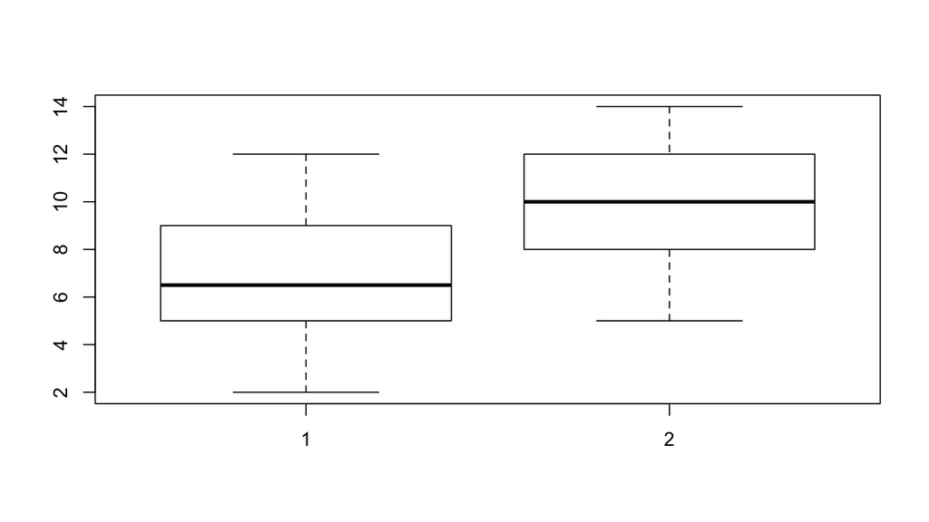

```r
boxplot(Baumann$Basal, Baumann$DRTA)
```

# Comparando duas amostras: prática

Os dados parecem normais. Portanto, realizo um teste-t *não-pareado* considerando o previsto em minhas hipóteses prévias.

```r
t.test(Baumann$DRTA, Baumann$Basal, alternative = "greater", paired = FALSE)
```

```
##
##  Welch Two Sample t-test
##
## data:  Baumann$DRTA and Baumann$Basal
## t = 3.7336, df = 41.99, p-value = 0.000281
## alternative hypothesis: true difference in means is greater than 0
## 95 percent confidence interval:
##  1.698472      Inf
## sample estimates:
## mean of x mean of y
##  9.772727  6.681818
```

- Há evidências de que o método de ensino DRTA melhora a performance de alunos em provas comparativamente ao método tradicional de ensino (t(41.99) = 3.73, p < 0.001).

# Comparando duas amostras: prática

“Covariaveis.csv” é uma tabela de Oushiro (2017)

Use a função read.csv() para importar a tabela pois se trata de tabela em formato .csv

```r
covariaveis = read.csv("~/Documents/Mahayana/academics/cursos/introstatistics/datasets/Covariaveis.csv")

str(covariaveis)
View(covariaveis)
```

# Comparando duas amostras: prática

```r
str(covariaveis)
```

```
## 'data.frame':    118 obs. of  15 variables:
##  $ INFORMANTE   : Factor w/ 118 levels "AdolfoF","AdrianaP",..: 1 2 3 4 5 6 7 8 9 10 ...
##  $ SEXO.GENERO  : Factor w/ 2 levels "feminino","masculino": 2 1 1 2 1 1 1 1 2 2 ...
##  $ IDADE        : int  21 24 20 60 73 32 45 61 70 63 ...
##  $ FAIXA.ETARIA : Factor w/ 3 levels "1a","2a","3a": 1 1 1 3 3 1 2 3 3 3 ...
##  $ ESCOLARIDADE : Factor w/ 2 levels "EnsMedio","EnsSuperior": 2 2 2 1 2 1 2 1 1 2 ...
##  $ REGIAO       : Factor w/ 2 levels "central","periferica": 1 1 2 2 2 2 2 2 2 2 ...
##  $ ZONA         : Factor w/ 5 levels "centro","leste",..: 1 1 2 3 3 4 5 5 3 3 ...
##  $ CLASSE.SOCIAL: Factor w/ 4 levels "a-b1","b2","c1",..: 2 3 3 4 2 4 1 3 4 2 ...
##  $ ORIGEM.PAIS  : Factor w/ 5 levels "estrangeiros",..: 2 3 5 2 5 5 5 2 5 2 ...
##  $ EN           : int  16 16 58 6 48 58 68 62 6 14 ...
##  $ RT           : int  44 4 34 80 18 54 28 20 42 12 ...
##  $ R0           : int  47 38 53 61 55 52 39 49 46 59 ...
##  $ CN           : int  45 6 7 12 1 15 4 0 17 7 ...
##  $ CV3PP        : int  8 8 19 14 7 18 8 5 24 23 ...
##  $ CV1PP        : int  0 0 0 0 0 0 0 0 40 0 ...
```

# Comparando duas amostras: prática

INFORMANTE: identificação do informante

SEXO.GENERO: sexo/gênero do participante

IDADE: idade do participante

FAIXA.ETARIA: 1a (até 34 anos); 2a (35 a 59 anos); 3a(mais de 60 anos)

ESCOLARIDADE: EnsMedio (ensino médio) EnsSuperior (ensino superior)

REGIAO: região de origem

(…)

# Comparando duas amostras: prática

EN: taxa de ditongação de /e/ nasal ([~ej], como em “fazenda”) em oposição à monotongação [~e]

RT: taxa de /r/ em coda realizado como retroflexo em oposição ao tepe;

R0: taxa de apagamento de /r/ em coda em oposição à realização;

CN: taxa de concordância nominal não padrão (e.g., “as menina”) em oposição à variante padrão

CV3PP: taxa de concordância de 3a pes. do plural não padrão (e.g., “eles vai”) em oposição à variante padrão

CV1PP: taxa de concordância de 1a pes. do plural não padrão (e.g., “nós vai”) em oposição à variante padrão

# Comparando duas amostras: prática

Com base nos dados de Oushiro (2017), é possível afirmar que a escolaridade influencia nas taxas de realização da concordância nominal?

Como testar?

- R: Comparar as taxas de CN dos informantes que tem ensino médio com as taxas dos informantes que tem ensino superior.

Quais as variáveis?

- R: Variável dependente: CN; Variável independente: ESCOLARIDADE

Qual a $H_0$ e $H_A$?

- R: $H_0$: $\mu_{EM}$ = $\mu_{ES}$ & $H_A$: $\mu_{EM}$ > $\mu_{ES}$

# Comparando duas amostras: prática

Precisamos criar datasets separados para informantes com ensino superior e informantes para ensino médio. Hora de relembrar como se usa o dplyr!

```r
ens.sup = covariaveis%>%
  filter(ESCOLARIDADE == "EnsSuperior")

ens.med = covariaveis%>%
  filter(ESCOLARIDADE == "EnsMedio")
```

# Comparando duas amostras: prática

Vamos fazer um box plot para ver se os dados são normais.

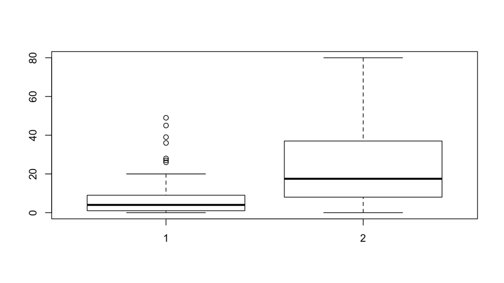

```r
boxplot(ens.sup$CN, ens.med$CN)
```

# Comparando duas amostras: prática

Só para conferir com os histogramas

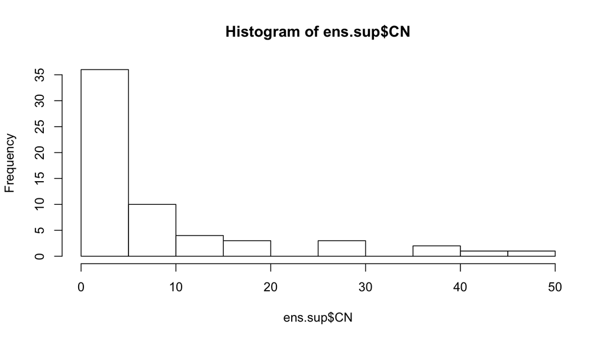

```r
hist(ens.sup$CN)
```

# Comparando duas amostras: prática

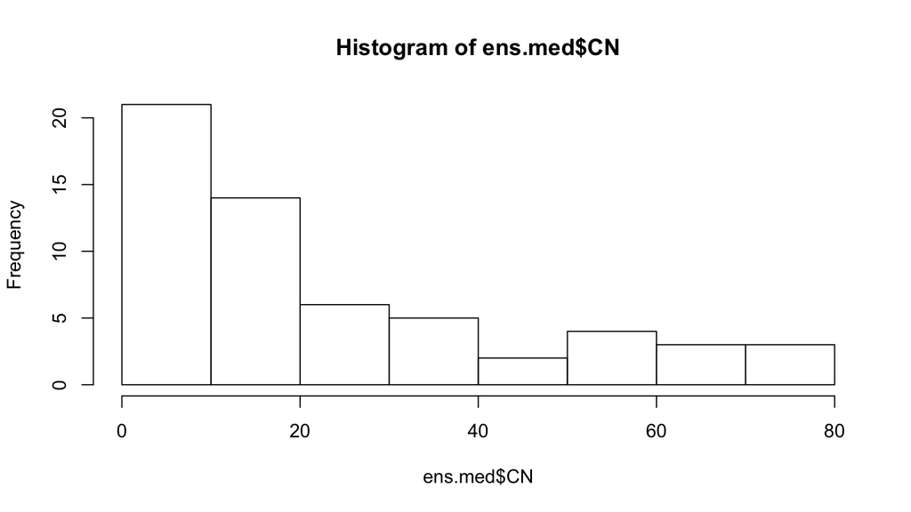

# Comparando duas amostras: prática

Uma opção para lidar com dados que poderiam ser analisados com um teste-t exceto pelo fato de não terem uma distribuição normal é o chamado Teste de Wilcoxon.

```r
wilcox.test(ens.med$CN, ens.sup$CN, alternative = "greater", paired = FALSE)
```

```
##
##  Wilcoxon rank sum test with continuity correction
##
## data:  ens.med$CN and ens.sup$CN
## W = 2686, p-value = 1.705e-07
## alternative hypothesis: true location shift is greater than 0
```

- Nos dados de Oushiro (2017), a taxa de realização da concordância nominal não padrão é determinada pelo nível de escolaridade (W = 2686, p < 0.0001).

# Comparando duas amostras: prática

Apenas lembrando que precisamos informar as estatísticas da nossa amostra. No caso de distribuições que não são normais, é importante informar a mediana dos grupos comparados.

```r
covariaveis%>%
  group_by(ESCOLARIDADE)%>%
  summarise(mediana = median(CN))
```

```
## # A tibble: 2 x 2
##   ESCOLARIDADE mediana
##   <fct>          <dbl>
## 1 EnsMedio        17.5
## 2 EnsSuperior      4
```

- Nos dados de Oushiro (2017), a taxa de realização da concordância nominal não padrão é determinada pelo nível de escolaridade (W = 2686, p < 0.0001). A taxa de realização da concordância não padrão é de 17.5% para informantes com Ensino Médio, contra 4% para informantes com Ensino Superior.

# Revisão

# Gráficos de diagnóstico

Para fazer boxplots e histogramas rapidamente, use:

```r
hist(x) #histograma de x
boxplot(x,y,z) #boxplot comparativo de x, y e z
```

# Testes

Para comparar dados independentes e numéricos, usem um teste-t para dados em uma distribuição normal e o teste de wilcoxon para dados que não tenham distribuição normal.

Não se esqueça de informar sua $H_A$ em `alternative` e se os dados são pareados

```r
t.test(x, y, paired = T/F, alternative = )
wilcox.test(x, y, paired = T/F, alternative = )
```

# Referências

# Referências

Oushiro, Livia (2017). Introdução à Estatística para Linguistas, v.1.0.1 (dez/2017). DOI: 10.5281/zenodo.1202201

Conjuntos de dados de Oushiro (2017): https://github.com/oushiro/datafiles